# Module 7: Time Series Regression, Pt 1

Xuan Pham

10/1/2019

```r
library(fpp2)
```

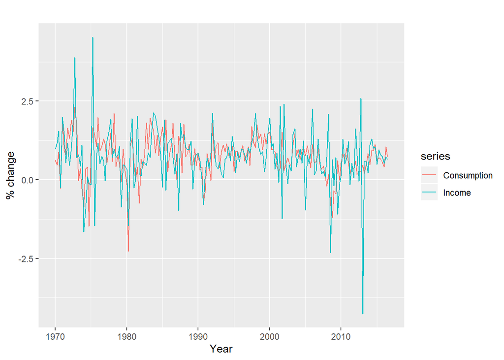

```r
autoplot(uschange[,c("Consumption","Income")]) +
  ylab("% change") + xlab("Year")
```

ConsumptionChange = f(IncomeChange)

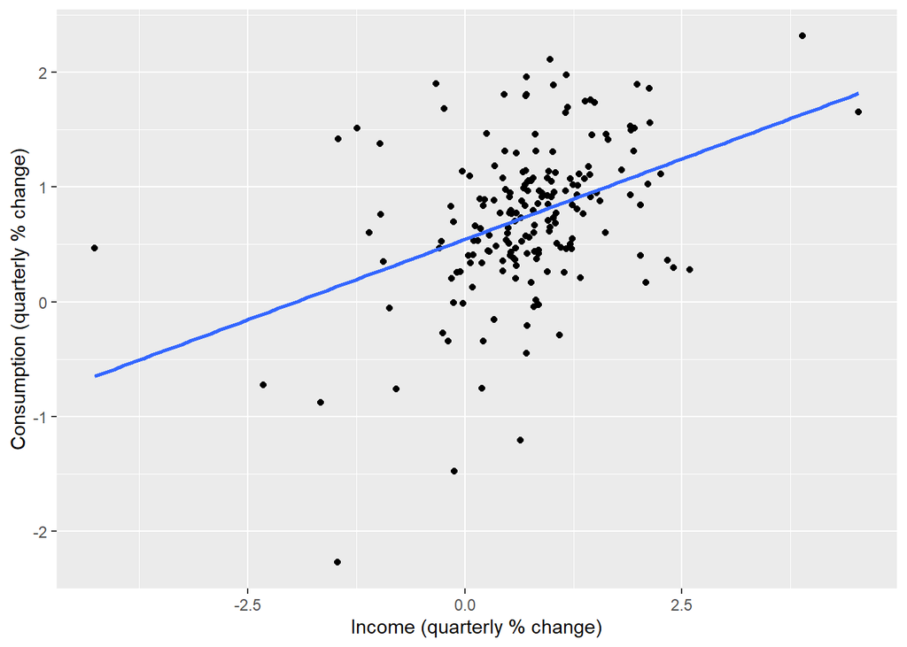

```r
uschange %>%
  as.data.frame() %>%
  ggplot(aes(x=Income, y=Consumption)) +
    ylab("Consumption (quarterly % change)") +
    xlab("Income (quarterly % change)") +
    geom_point() +
    geom_smooth(method="lm", se=FALSE)
```

We can fit the linear regression model using tslm() function.

```r
fit1 <- tslm(Consumption ~ Income, data=uschange)
summary(fit1)
```

```
##
## Call:
## tslm(formula = Consumption ~ Income, data = uschange)
##
## Residuals:
##      Min       1Q   Median       3Q      Max
## -2.40845 -0.31816  0.02558  0.29978  1.45157
##
## Coefficients:
##             Estimate Std. Error t value Pr(>|t|)
## (Intercept)  0.54510    0.05569   9.789  < 2e-16 ***
## Income       0.28060    0.04744   5.915 1.58e-08 ***
## ---
## Signif. codes:  0 '***' 0.001 '**' 0.01 '*' 0.05 '.' 0.1 ' ' 1
##
## Residual standard error: 0.6026 on 185 degrees of freedom
## Multiple R-squared:  0.159,  Adjusted R-squared:  0.1545
## F-statistic: 34.98 on 1 and 185 DF,  p-value: 1.577e-08
```

Can you interpret the y-intercept and fitted regression coefficient?

Let’s do a multiple linear regression example.

```r
library(GGally)
```

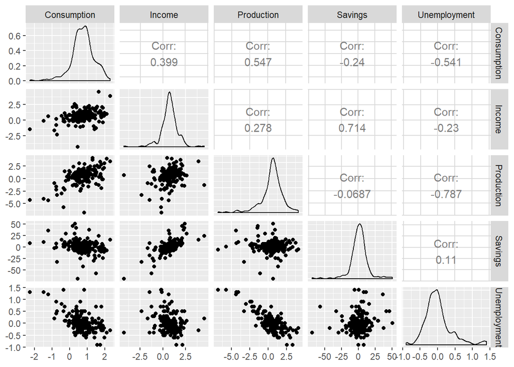

```r
uschange %>%
  as.data.frame() %>%
  GGally::ggpairs()
```

```r
fit.consMR <- tslm(
  Consumption ~ Income + Production + Unemployment + Savings,
  data=uschange)
summary(fit.consMR)
```

```
##
## Call:
## tslm(formula = Consumption ~ Income + Production + Unemployment +
##     Savings, data = uschange)
##
## Residuals:
##      Min       1Q   Median       3Q      Max
## -0.88296 -0.17638 -0.03679  0.15251  1.20553
##
## Coefficients:
##              Estimate Std. Error t value Pr(>|t|)
## (Intercept)   0.26729    0.03721   7.184 1.68e-11 ***
## Income        0.71449    0.04219  16.934  < 2e-16 ***
## Production    0.04589    0.02588   1.773   0.0778 .
## Unemployment -0.20477    0.10550  -1.941   0.0538 .
## Savings      -0.04527    0.00278 -16.287  < 2e-16 ***
## ---
## Signif. codes:  0 '***' 0.001 '**' 0.01 '*' 0.05 '.' 0.1 ' ' 1
##
## Residual standard error: 0.3286 on 182 degrees of freedom
## Multiple R-squared:  0.754,  Adjusted R-squared:  0.7486
## F-statistic: 139.5 on 4 and 182 DF,  p-value: < 2.2e-16
```

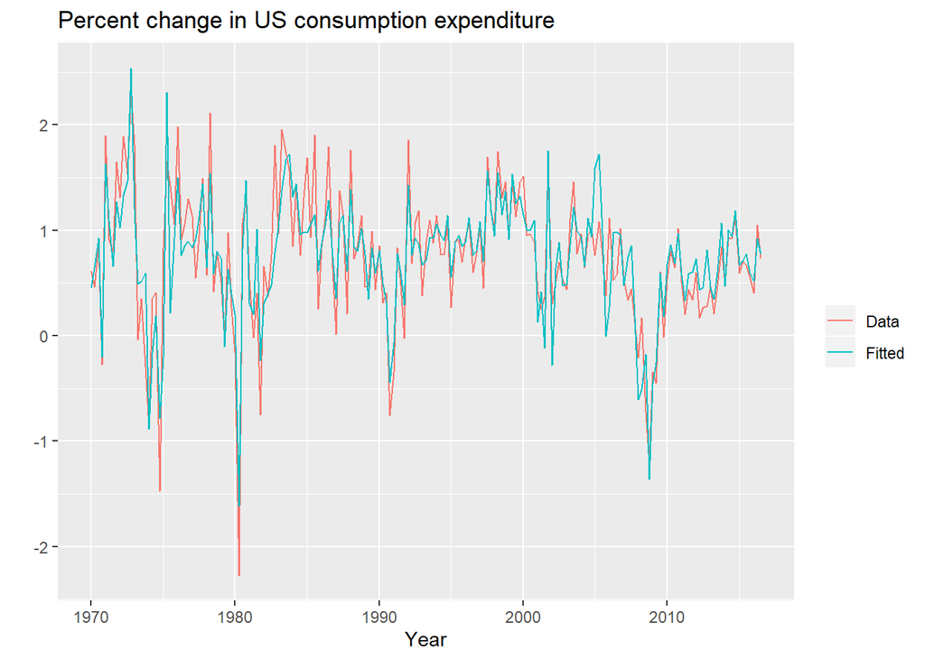

```r
autoplot(uschange[,'Consumption'], series="Data") +
  autolayer(fitted(fit.consMR), series="Fitted") +
  xlab("Year") + ylab("") +
  ggtitle("Percent change in US consumption expenditure") +
  guides(colour=guide_legend(title=" "))
```

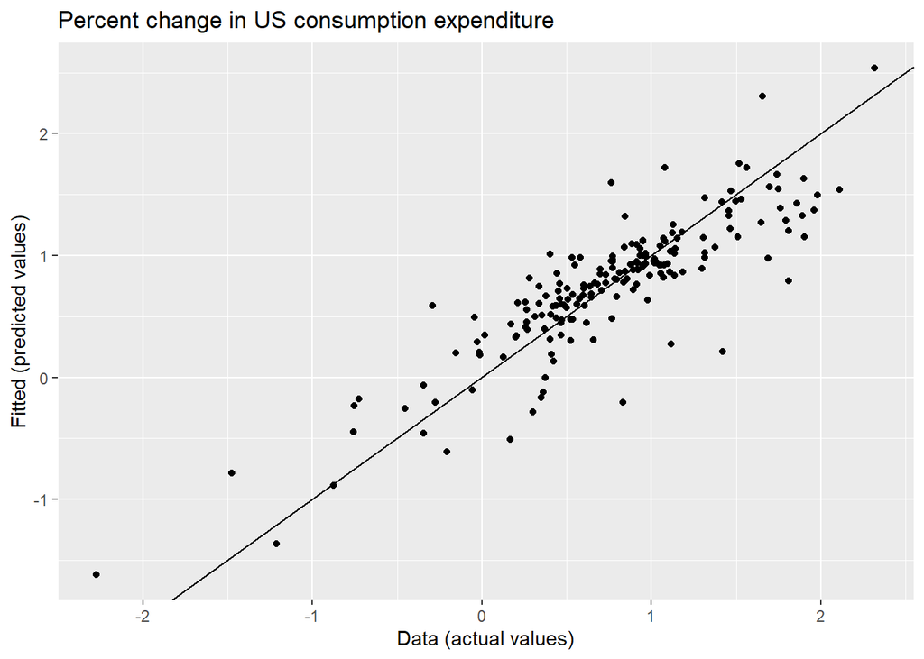

```r
cbind(Data = uschange[,"Consumption"],
      Fitted = fitted(fit.consMR)) %>%
  as.data.frame() %>%
  ggplot(aes(x=Data, y=Fitted)) +
    geom_point() +
    ylab("Fitted (predicted values)") +
    xlab("Data (actual values)") +
    ggtitle("Percent change in US consumption expenditure") +
    geom_abline(intercept=0, slope=1)
```

# Some Reminders

Things to always keep in mind when working with linear regression time series models.  
*Errors (e_t) have mean zero or else the forecast is systematically biased.*  
Errors are not autocorrelated or else forecast is systematically inefficient.  
*Errors are uncorrelated with the predictor variables or else we are leaving out important patterns from our model.*  
The regression model is estimated using Ordinary Least Squares (OLS), which is minimizing the sum of squared errors.

# Model Evaluation

## Always check the residuals

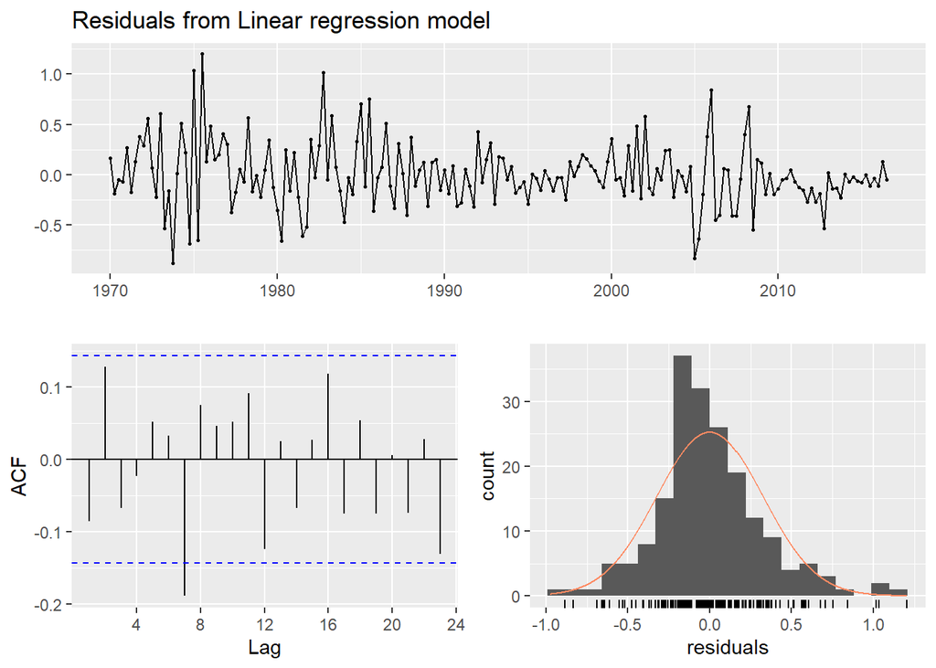

```
##
##  Breusch-Godfrey test for serial correlation of order up to 8
##
## data:  Residuals from Linear regression model
## LM test = 14.874, df = 8, p-value = 0.06163
```

```r
checkresiduals(fit.consMR)
```

Instead of the Ljung-Box test for serial correlation, we use the Breusch-Godfrey test. This test is used to examine serial correlation (autocorrelation) of residuals from regression models.

H0: p(0) = p(1)=…=p(k) = 0. There is no significant autocorrelation function (ACF) lag. There is no autocorrelation.  
H1: At least one p(k) IS NOT EQUAL to 0. At least one autocorrelation function (ACF) lag is different from 0. There is autocorrelation.

The goal is not to reject the null hypothesis. In this case, what does the Breusch-Godfrey test tell us about autocorrelation in the residuals?

## Residual plots

### Against predictors

These plots should look random. If the plot(s) show patterns, then the relationship in the underlying time series may not be linear. The fitted model needs to be adjusted/revised.

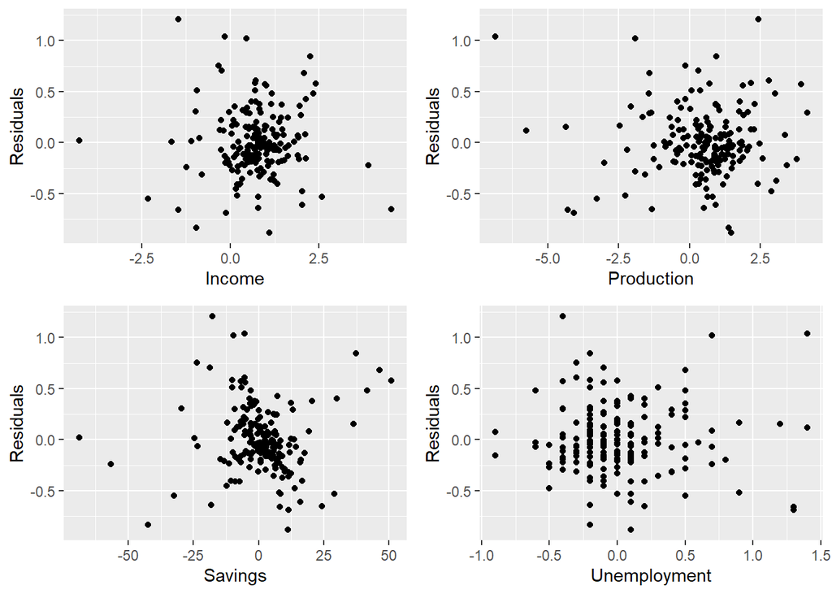

```r
df <- as.data.frame(uschange)
df[,"Residuals"]  <- as.numeric(residuals(fit.consMR))
p1 <- ggplot(df, aes(x=Income, y=Residuals)) +
  geom_point()
p2 <- ggplot(df, aes(x=Production, y=Residuals)) +
  geom_point()
p3 <- ggplot(df, aes(x=Savings, y=Residuals)) +
  geom_point()
p4 <- ggplot(df, aes(x=Unemployment, y=Residuals)) +
  geom_point()
gridExtra::grid.arrange(p1, p2, p3, p4, nrow=2)
```

### Against fitted values

A plot of the residuals against the fitted values should also show no pattern. If a pattern is observed, there may be “heteroscedasticity” in the errors which means that the variance of the residuals may not be constant. If this problem occurs, a transformation of the forecast variable such as a logarithm or square root may be required.

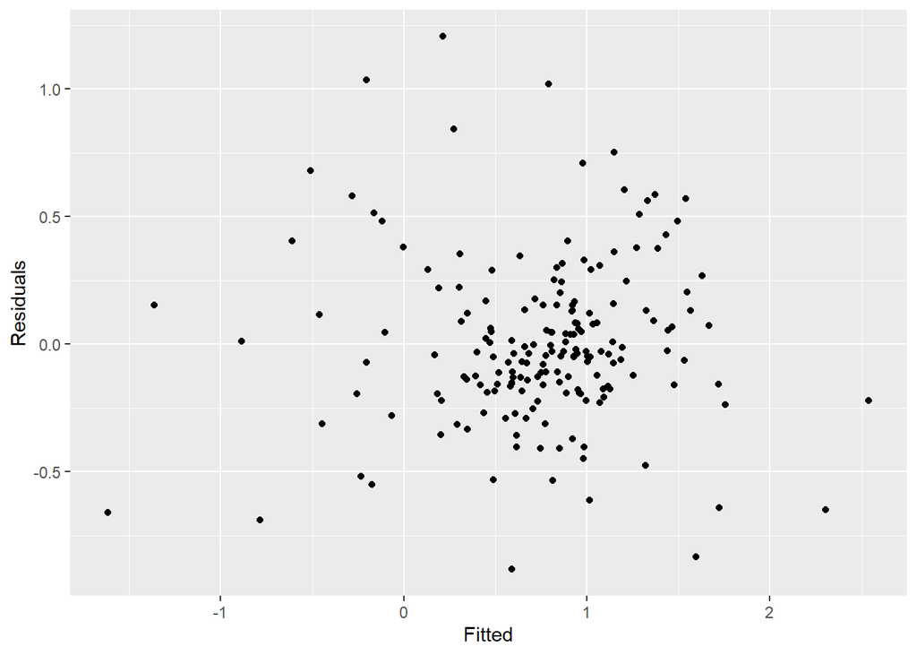

```r
cbind(Fitted = fitted(fit.consMR),
      Residuals=residuals(fit.consMR)) %>%
  as.data.frame() %>%
  ggplot(aes(x=Fitted, y=Residuals)) + geom_point()
```

# Useful Predictors for Time Series Regression Models

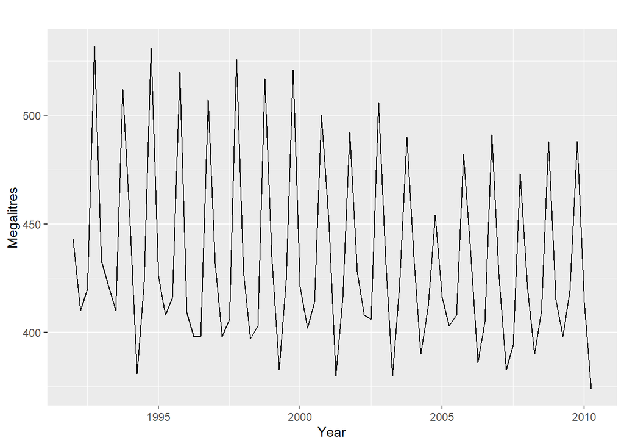

```r
beer2 <- window(ausbeer, start=1992)
autoplot(beer2) + xlab("Year") + ylab("Megalitres")
```

## Trend

A linear trend can be included as a predictor.

## Dummy Variables

We can include dummy variables to account for:  
*holidays*  
outliers (a one time event)  
*intervention/shock (one time event or lasting effect)*  
seasonality

A note about creating seasonality dummy variables. You should always do this calculation:

Number of required dummy variables = number of seasons - 1

The effects of the omitted season are included in the y-intercept.

The interpretation of each of the coefficients associated with the dummy variables is that it is a measure of the effect of that category relative to the omitted category.

```r
fit.beer <- tslm(beer2 ~ trend + season)
summary(fit.beer)
```

```
##
## Call:
## tslm(formula = beer2 ~ trend + season)
##
## Residuals:
##     Min      1Q  Median      3Q     Max
## -42.903  -7.599  -0.459   7.991  21.789
##
## Coefficients:
##              Estimate Std. Error t value Pr(>|t|)
## (Intercept) 441.80044    3.73353 118.333  < 2e-16 ***
## trend        -0.34027    0.06657  -5.111 2.73e-06 ***
## season2     -34.65973    3.96832  -8.734 9.10e-13 ***
## season3     -17.82164    4.02249  -4.430 3.45e-05 ***
## season4      72.79641    4.02305  18.095  < 2e-16 ***
## ---
## Signif. codes:  0 '***' 0.001 '**' 0.01 '*' 0.05 '.' 0.1 ' ' 1
##
## Residual standard error: 12.23 on 69 degrees of freedom
## Multiple R-squared:  0.9243, Adjusted R-squared:  0.9199
## F-statistic: 210.7 on 4 and 69 DF,  p-value: < 2.2e-16
```

Can you interpret the y-intercept and estimated regression coefficients?

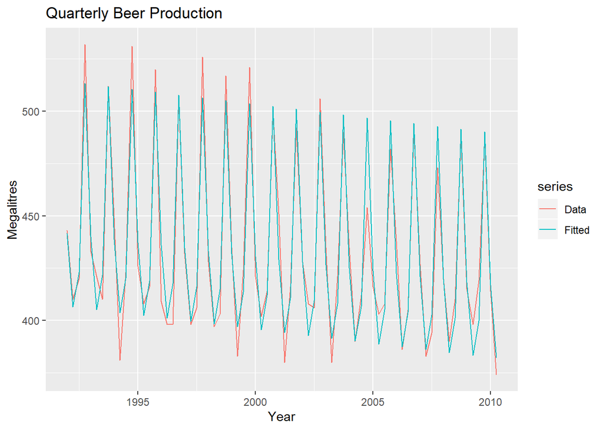

```r
autoplot(beer2, series="Data") +
  autolayer(fitted(fit.beer), series="Fitted") +
  xlab("Year") + ylab("Megalitres") +
  ggtitle("Quarterly Beer Production")
```

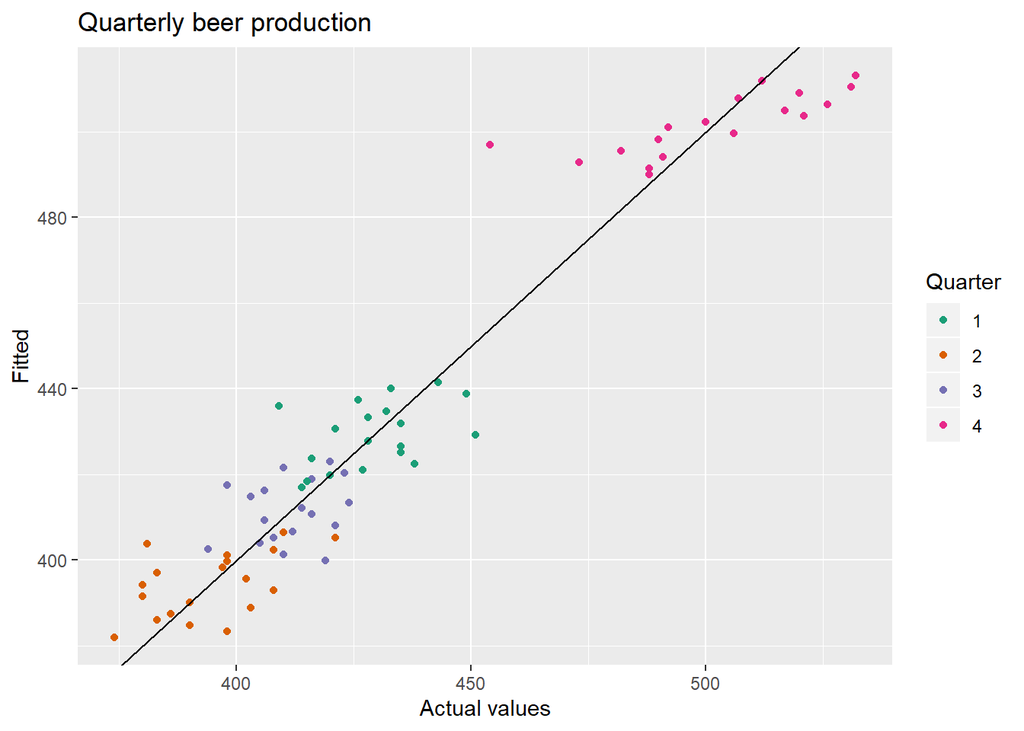

```r
cbind(Data=beer2, Fitted=fitted(fit.beer)) %>%
  as.data.frame() %>%
  ggplot(aes(x = Data, y = Fitted,
             colour = as.factor(cycle(beer2)))) +
    geom_point() +
    ylab("Fitted") + xlab("Actual values") +
    ggtitle("Quarterly beer production") +
    scale_colour_brewer(palette="Dark2", name="Quarter") +
    geom_abline(intercept=0, slope=1)
```

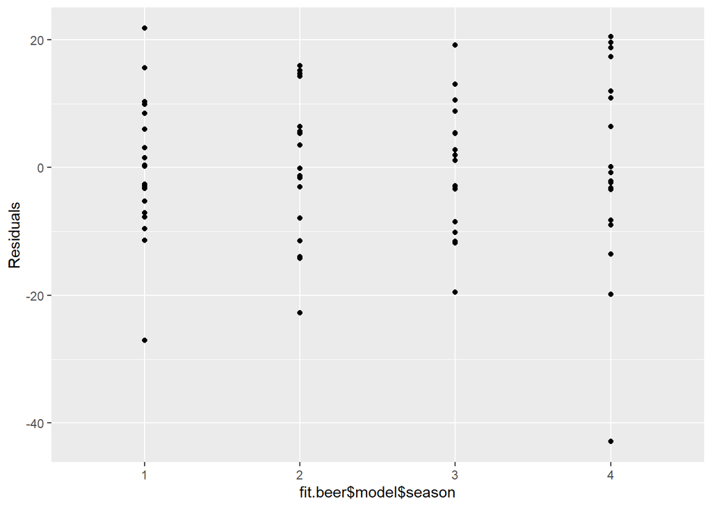

```r
beer2 <- window(ausbeer, start=1992)
df <- as.data.frame(beer2)
df[,"Residuals"]  <- as.numeric(residuals(fit.beer))
ggplot(df, aes(x=fit.beer$model$season, y=Residuals)) +
  geom_point()
```

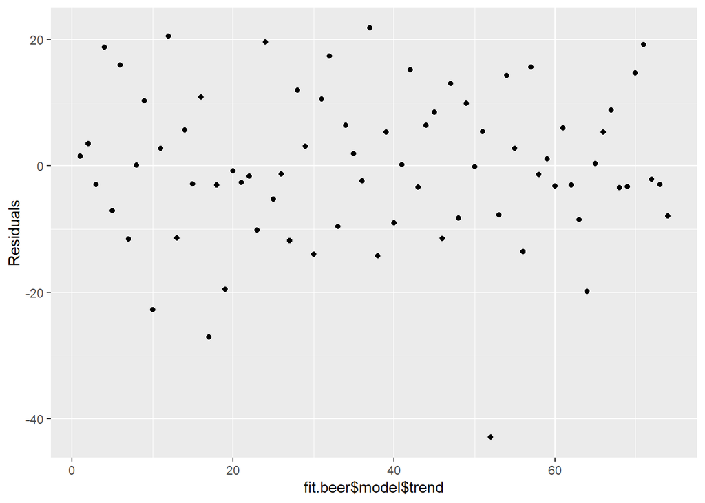

```r
df[,"Residuals"]  <- as.numeric(residuals(fit.beer))
ggplot(df, aes(x=fit.beer$model$trend, y=Residuals)) +
  geom_point()
```

## Fourier Series

Maximum K = m/2 where m is the number of seasonal periods.

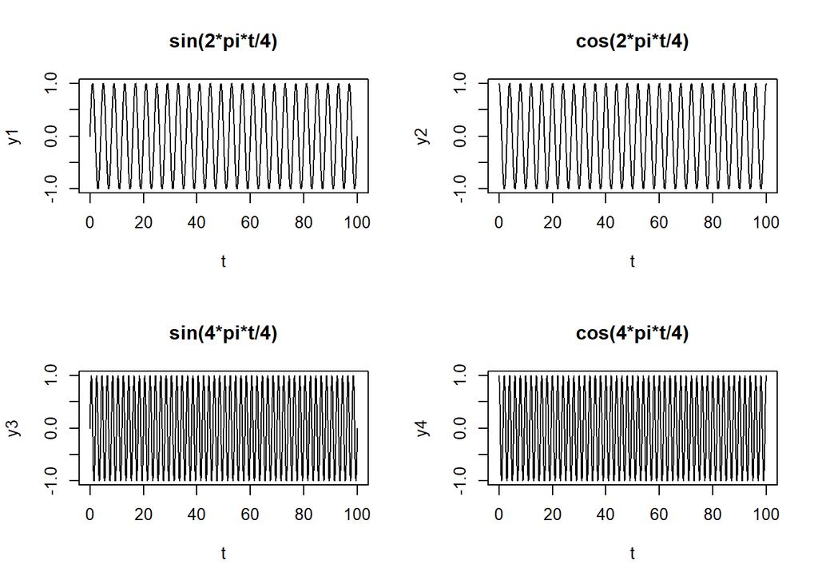

```r
t = seq(0,100,.05)
y1 = sin(2*pi*t/4)
y2 = cos(2*pi*t/4)
y3 = sin(4*pi*t/4)
y4 = cos(4*pi*t/4)
par(mfrow=c(2,2))
plot(t,y1,type="l",main="sin(2*pi*t/4)")
plot(t,y2,type="l",main="cos(2*pi*t/4)")
plot(t,y3,type="l",main="sin(4*pi*t/4)")
plot(t,y4,type="l",main="cos(4*pi*t/4)")
```

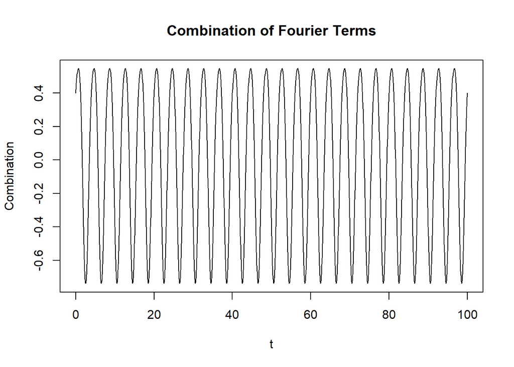

```r
#Change the weights to combine the sine and cosine terms.
par(mfrow=c(1,1))
plot(t,.5*y1 + .4*y2 - .1*y3 + .0*y4,ylab="Combination",type="l",main="Combination of Fourier Terms")
```

```r
fourier.beer <- tslm(beer2 ~ trend + fourier(beer2, K=2))
summary(fourier.beer)
```

```
##
## Call:
## tslm(formula = beer2 ~ trend + fourier(beer2, K = 2))
##
## Residuals:
##     Min      1Q  Median      3Q     Max
## -42.903  -7.599  -0.459   7.991  21.789
##
## Coefficients:
##                            Estimate Std. Error t value Pr(>|t|)
## (Intercept)               446.87920    2.87321 155.533  < 2e-16 ***
## trend                      -0.34027    0.06657  -5.111 2.73e-06 ***
## fourier(beer2, K = 2)S1-4   8.91082    2.01125   4.430 3.45e-05 ***
## fourier(beer2, K = 2)C1-4  53.72807    2.01125  26.714  < 2e-16 ***
## fourier(beer2, K = 2)C2-4  13.98958    1.42256   9.834 9.26e-15 ***
## ---
## Signif. codes:  0 '***' 0.001 '**' 0.01 '*' 0.05 '.' 0.1 ' ' 1
##
## Residual standard error: 12.23 on 69 degrees of freedom
## Multiple R-squared:  0.9243, Adjusted R-squared:  0.9199
## F-statistic: 210.7 on 4 and 69 DF,  p-value: < 2.2e-16
```

```r
CV(fit.consMR)
```

```
##           CV          AIC         AICc          BIC        AdjR2
##    0.1163477 -409.2980298 -408.8313631 -389.9113781    0.7485856
```

## Best Subset Regression Model

We can run these subsets:  
* backward selection - Start with all the predictors and remove each predictor one at a time. Keep new model if chosen measure of performance improved. Iterate until performance cannot be improved further.  
* forward selection - Start with no predictors. Add one predictor at a time. Iterate until performance cannot improve any further.  
* both - Combine backward and forward selection algorithms.

```r
#only run on a dataframe object. Not time series object!
uschange.df <- as.data.frame(uschange)

fit.lm <- lm(Consumption ~., data=uschange.df)
summary(fit.lm)
```

```
##
## Call:
## lm(formula = Consumption ~ ., data = uschange.df)
##
## Residuals:
##      Min       1Q   Median       3Q      Max
## -0.88296 -0.17638 -0.03679  0.15251  1.20553
##
## Coefficients:
##              Estimate Std. Error t value Pr(>|t|)
## (Intercept)   0.26729    0.03721   7.184 1.68e-11 ***
## Income        0.71449    0.04219  16.934  < 2e-16 ***
## Production    0.04589    0.02588   1.773   0.0778 .
## Savings      -0.04527    0.00278 -16.287  < 2e-16 ***
## Unemployment -0.20477    0.10550  -1.941   0.0538 .
## ---
## Signif. codes:  0 '***' 0.001 '**' 0.01 '*' 0.05 '.' 0.1 ' ' 1
##
## Residual standard error: 0.3286 on 182 degrees of freedom
## Multiple R-squared:  0.754,  Adjusted R-squared:  0.7486
## F-statistic: 139.5 on 4 and 182 DF,  p-value: < 2.2e-16
```

```r
step(fit.lm, direction = "forward")
```

```
## Start:  AIC=-411.3
## Consumption ~ Income + Production + Savings + Unemployment
```

```
##
## Call:
## lm(formula = Consumption ~ Income + Production + Savings + Unemployment,
##     data = uschange.df)
##
## Coefficients:
##  (Intercept)        Income    Production       Savings  Unemployment
##      0.26729       0.71448       0.04589      -0.04527      -0.20477
```

```r
step(fit.lm, direction = "backward")
```

```
## Start:  AIC=-411.3
## Consumption ~ Income + Production + Savings + Unemployment
##
##                Df Sum of Sq    RSS     AIC
## <none>                      19.652 -411.30
## - Production    1    0.3396 19.992 -410.09
## - Unemployment  1    0.4068 20.059 -409.47
## - Savings       1   28.6413 48.293 -245.16
## - Income        1   30.9656 50.618 -236.37
```

```
##
## Call:
## lm(formula = Consumption ~ Income + Production + Savings + Unemployment,
##     data = uschange.df)
##
## Coefficients:
##  (Intercept)        Income    Production       Savings  Unemployment
##      0.26729       0.71448       0.04589      -0.04527      -0.20477
```

```r
step(fit.lm, direction = "both")
```

```
## Start:  AIC=-411.3
## Consumption ~ Income + Production + Savings + Unemployment
##
##                Df Sum of Sq    RSS     AIC
## <none>                      19.652 -411.30
## - Production    1    0.3396 19.992 -410.09
## - Unemployment  1    0.4068 20.059 -409.47
## - Savings       1   28.6413 48.293 -245.16
## - Income        1   30.9656 50.618 -236.37
```

```
##
## Call:
## lm(formula = Consumption ~ Income + Production + Savings + Unemployment,
##     data = uschange.df)
##
## Coefficients:
##  (Intercept)        Income    Production       Savings  Unemployment
##      0.26729       0.71448       0.04589      -0.04527      -0.20477
```

# Forecasting with Regression Models

Ex-ante forecast: Forecast made with whatever information available at the time of the forecast being made.  
Ex-post forecast: Forecast made with later information on the predictors.

In the example below, we can deterministically figure out the trend. We also know the seasonal dummy variables. Hence, there is no difference in ex-ante and ex-post forecasting in this scenario.

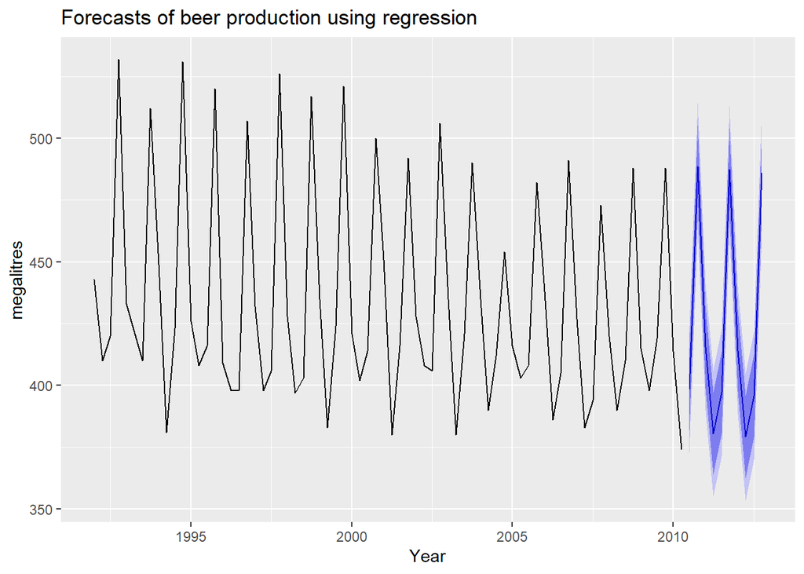

```r
beer2 <- window(ausbeer, start=1992)
fit.beer <- tslm(beer2 ~ trend + season)
fcast <- forecast(fit.beer)
autoplot(fcast) +
  ggtitle("Forecasts of beer production using regression") +
  xlab("Year") + ylab("megalitres")
```

## Scenario Forecasting

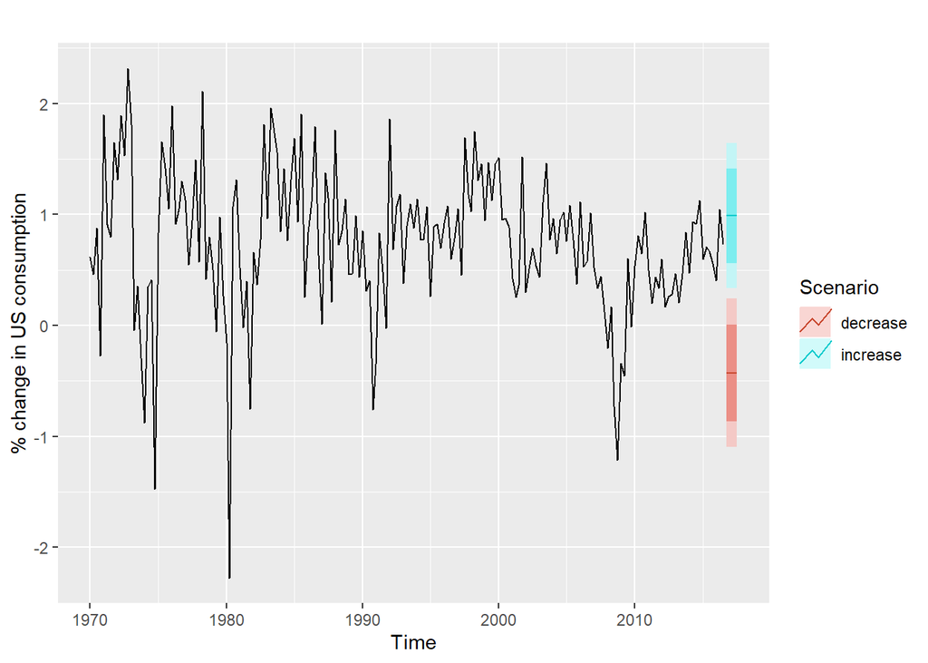

```r
fit.consBest <- tslm(
  Consumption ~ Income + Savings + Unemployment,
  data = uschange)
h <- 4
newdata <- data.frame(
    Income = c(1, 1, 1, 1),
    Savings = c(0.5, 0.5, 0.5, 0.5),
    Unemployment = c(0, 0, 0, 0))
fcast.up <- forecast(fit.consBest, newdata = newdata)
newdata <- data.frame(
    Income = rep(-1, h),
    Savings = rep(-0.5, h),
    Unemployment = rep(0, h))
fcast.down <- forecast(fit.consBest, newdata = newdata)
autoplot(uschange[, 1]) +
  ylab("% change in US consumption") +
  autolayer(fcast.up, PI = TRUE, series = "increase") +
  autolayer(fcast.down, PI = TRUE, series = "decrease") +
  guides(colour = guide_legend(title = "Scenario"))
```

# Nonlinear Regression

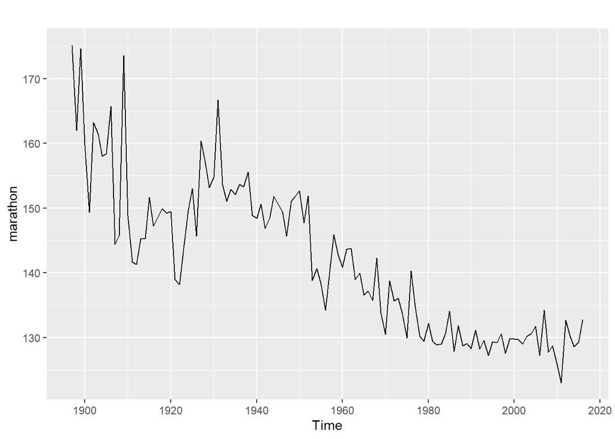

```r
autoplot(marathon)
```

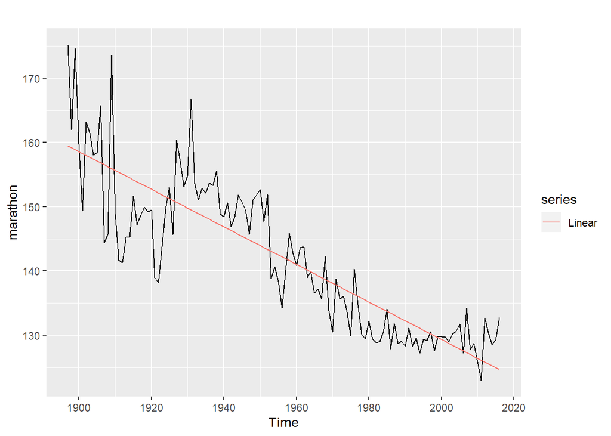

```r
fit.lin <- tslm(marathon ~ trend)
autoplot(marathon) +
  autolayer(fitted(fit.lin), series = "Linear")
```

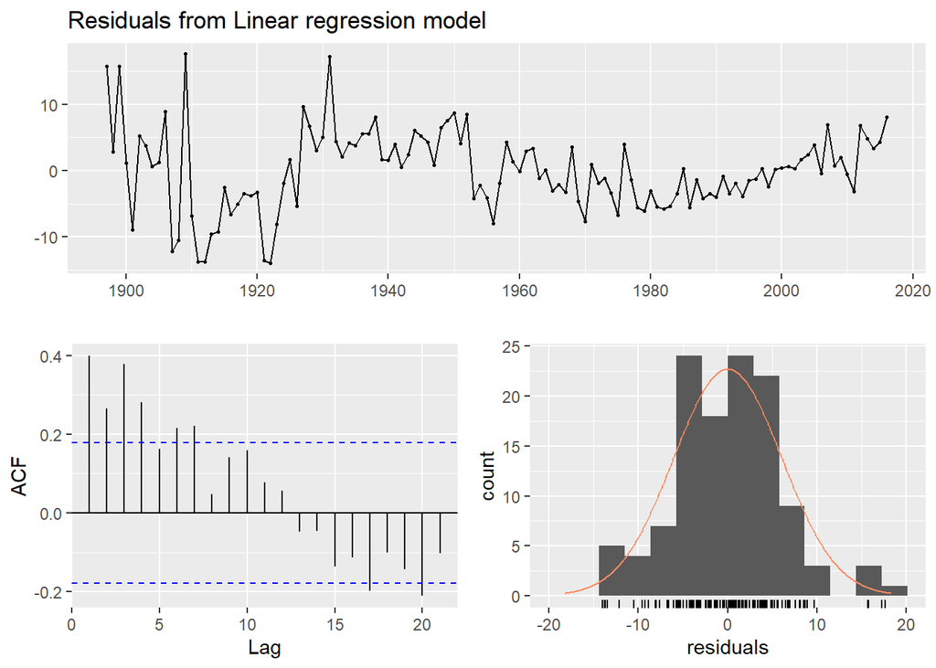

```
##
##  Breusch-Godfrey test for serial correlation of order up to 10
##
## data:  Residuals from Linear regression model
## LM test = 32.783, df = 10, p-value = 0.0002962
```

```r
checkresiduals(fit.lin)
```

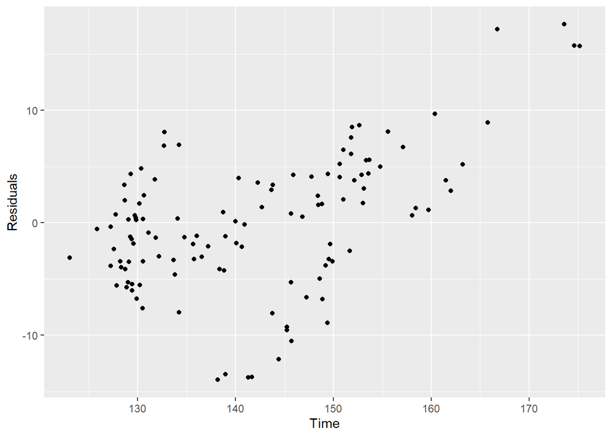

```r
#Residuals vs. Predictor Plot
df <- as.data.frame(marathon)
colnames(df) <- "Time"
df[,"Residuals"]  <- as.numeric(residuals(fit.lin))
ggplot(df, aes(x=Time, y=Residuals)) +
  geom_point()
```

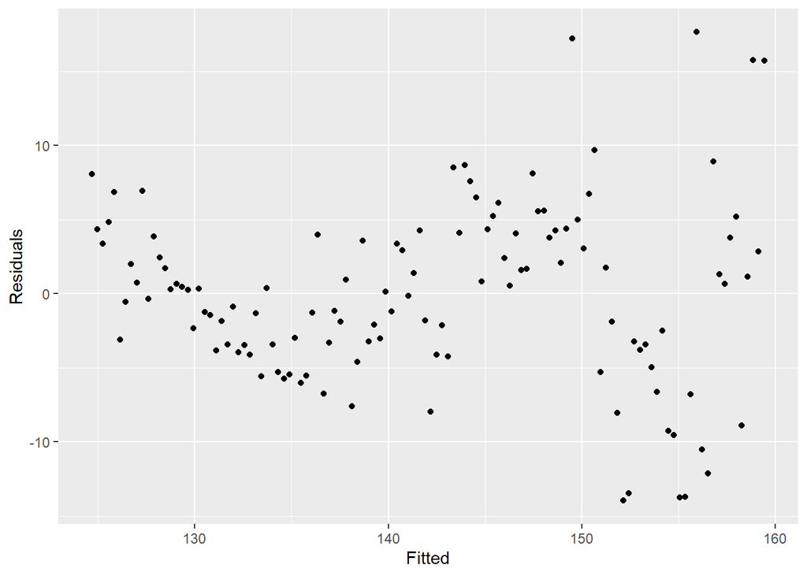

```r
#Residuals vs. Fitted Values Plot

cbind(Fitted = fitted(fit.lin),
      Residuals=residuals(fit.lin)) %>%
  as.data.frame() %>%
  ggplot(aes(x=Fitted, y=Residuals)) + geom_point()
```

What do these plots tell you about the residuals?

## Fitting an exponential trend

This requires doing a log transformation on the target (dependent) variable.

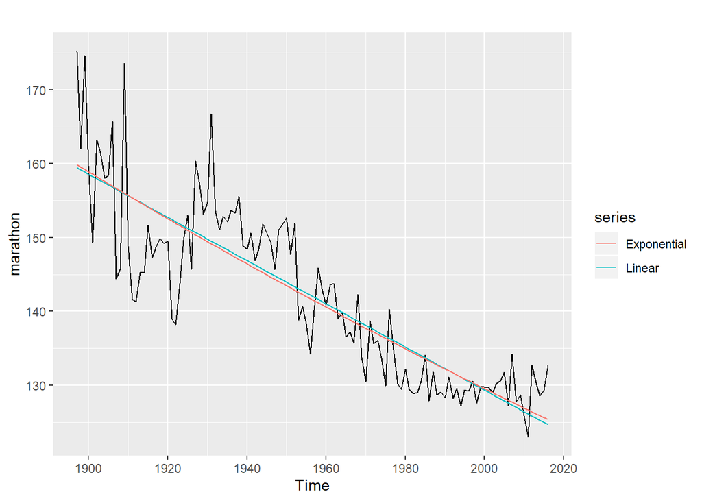

```r
fit.exp <- tslm(marathon ~ trend, lambda = 0)

autoplot(marathon) +
  autolayer(fitted(fit.lin), series = "Linear") +
  autolayer(fitted(fit.exp), series = "Exponential")
```

The log-linear model did not look much different but the forecasts are now decreasing at a decreasing rate.

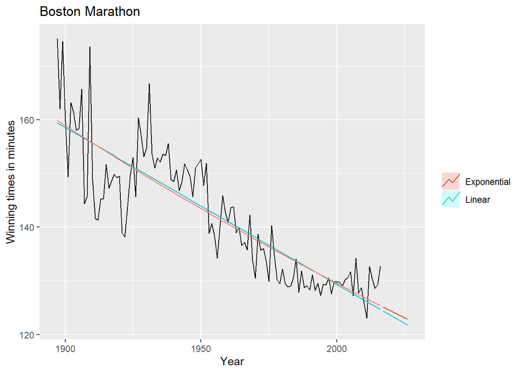

```r
h <- 10
fcasts.lin <- forecast(fit.lin, h=h)
fcasts.exp <- forecast(fit.exp, h=h)

autoplot(marathon) +
  autolayer(fitted(fit.lin), series = "Linear") +
  autolayer(fcasts.lin, series="Linear", PI=FALSE)+
  autolayer(fitted(fit.exp), series = "Exponential") +
  autolayer(fcasts.exp, series="Exponential", PI=FALSE)+
  xlab("Year") + ylab("Winning times in minutes") +
  ggtitle("Boston Marathon") +
  guides(colour = guide_legend(title = " "))
```

Can you check the residuals? How do they compare to the linear model?

## Regression Splines

We allow the slope to bend at various points in the time series. In essence, we are fitting several time series linear regression models with different trends.

Winning time was volatile until 1940. After that, it decreased in a linear fashion until 1980. The winning time seems flattened after 1980.

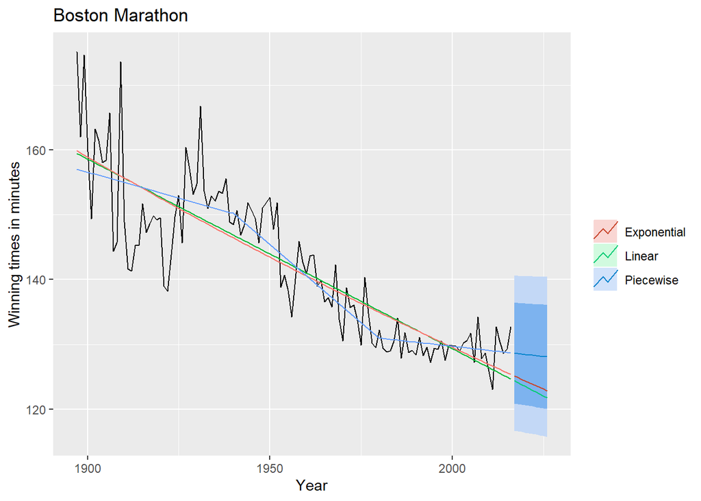

```r
t <- time(marathon)
t.break1 <- 1940
t.break2 <- 1980
tb1 <- ts(pmax(0, t - t.break1), start = 1897)
tb2 <- ts(pmax(0, t - t.break2), start = 1897)

fit.pw <- tslm(marathon ~ t + tb1 + tb2)
t.new <- t[length(t)] + seq(h)
tb1.new <- tb1[length(tb1)] + seq(h)
tb2.new <- tb2[length(tb2)] + seq(h)

newdata <- cbind(t=t.new, tb1=tb1.new, tb2=tb2.new) %>%
  as.data.frame()
fcasts.pw <- forecast(fit.pw, newdata = newdata)


autoplot(marathon) +
  autolayer(fitted(fit.lin), series = "Linear") +
  autolayer(fitted(fit.exp), series = "Exponential") +
  autolayer(fitted(fit.pw), series = "Piecewise") +
  autolayer(fcasts.pw, series="Piecewise") +
  autolayer(fcasts.lin, series="Linear", PI=FALSE) +
  autolayer(fcasts.exp, series="Exponential", PI=FALSE) +
  xlab("Year") + ylab("Winning times in minutes") +
  ggtitle("Boston Marathon") +
  guides(colour = guide_legend(title = " "))
```

We can make the “knots” look less abrupt by replacing the piecewise lines with piecewise cubics. It does a better job of fitting the historical time series but does not give as good of forecasting performance.

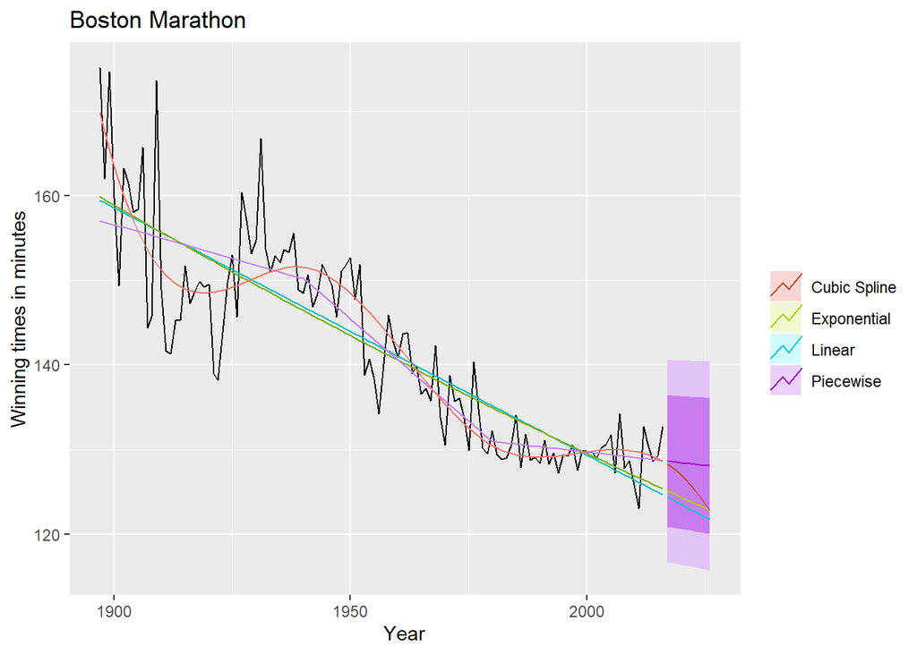

```r
fit.spline <- tslm(marathon ~ t + I(t^2) + I(t^3) +
  I(tb1^3) + I(tb2^3))
fcasts.spl <- forecast(fit.spline, newdata = newdata)

autoplot(marathon) +
  autolayer(fitted(fit.lin), series = "Linear") +
  autolayer(fitted(fit.exp), series = "Exponential") +
  autolayer(fitted(fit.pw), series = "Piecewise") +
  autolayer(fitted(fit.spline), series = "Cubic Spline") +
  autolayer(fcasts.pw, series="Piecewise") +
  autolayer(fcasts.lin, series="Linear", PI=FALSE) +
  autolayer(fcasts.exp, series="Exponential", PI=FALSE) +
  autolayer(fcasts.spl, series="Cubic Spline", PI=FALSE) +
  xlab("Year") + ylab("Winning times in minutes") +
  ggtitle("Boston Marathon") +
  guides(colour = guide_legend(title = " "))
```

## Natural Cubic Smoothing Splines

This forces the cubic splines to be linear at both ends. The model gives better forecasts.

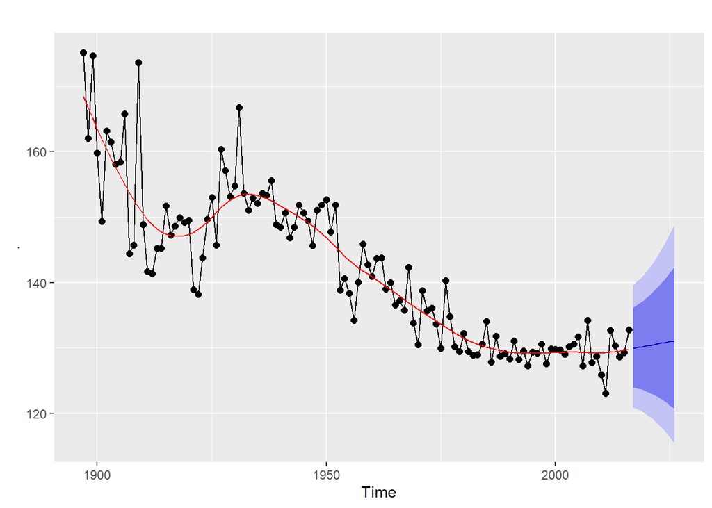

```r
#notice we also log transformed the dependent variable (winning time) to stabilize the variance
marathon %>%
  splinef(lambda=0) %>%
  autoplot()
```

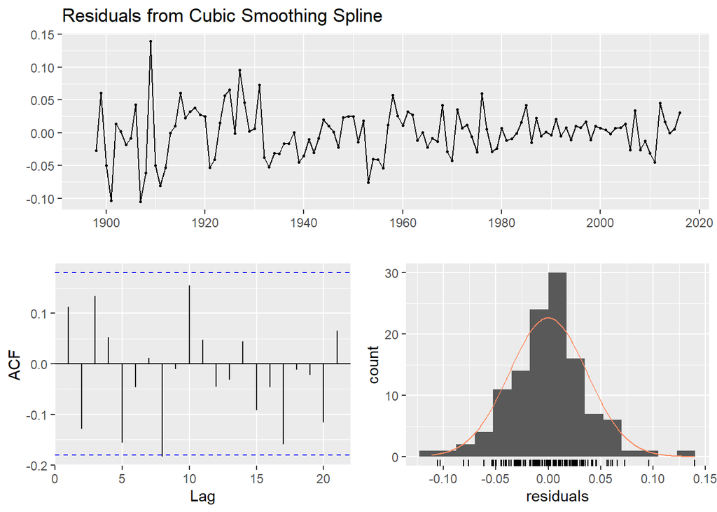

```r
marathon %>%
  splinef(lambda=0) %>%
  checkresiduals()
```

# Last Words

- Confounding factors/variables
- Multicollinearity